# ADS-project1

nyuchai nc2774

12/09/2019

A. Processed Data

```r
devtools::install_github("lchiffon/wordcloud2")
library(wordcloud2)
library(ggplot2)
```

```r
load("~/Desktop/columbia/5234 ads/project 1/lyrics.RData")

all_word <- lapply(dt_lyrics$stemmedwords, function(x){
  strsplit(x,' ')
})

to_score <- all_word

all_word <- unlist(all_word)

count_word <-data.frame(table(all_word))
count_word<- count_word[order(count_word$Freq,decreasing = TRUE),]

plot_word <- subset(count_word,count_word$Freq>=20)
frequency_data <- plot_word[order(plot_word$Freq,decreasing = TRUE),][1:30,]
####wordcloud
wordcloud2(plot_word)
```

[interactive chart not shown]

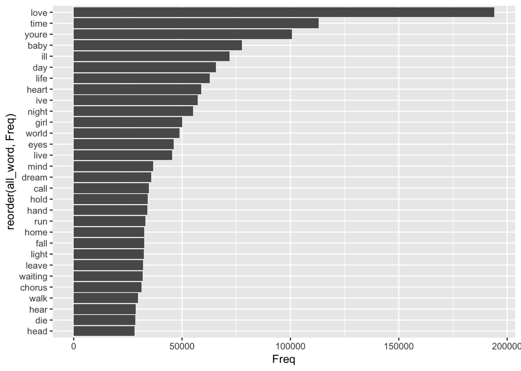

```r
####the first 30 words  histogram
ggplot(frequency_data, aes(x = reorder(all_word,Freq), y = Freq)) +
  geom_bar(stat ="identity")+coord_flip()
```

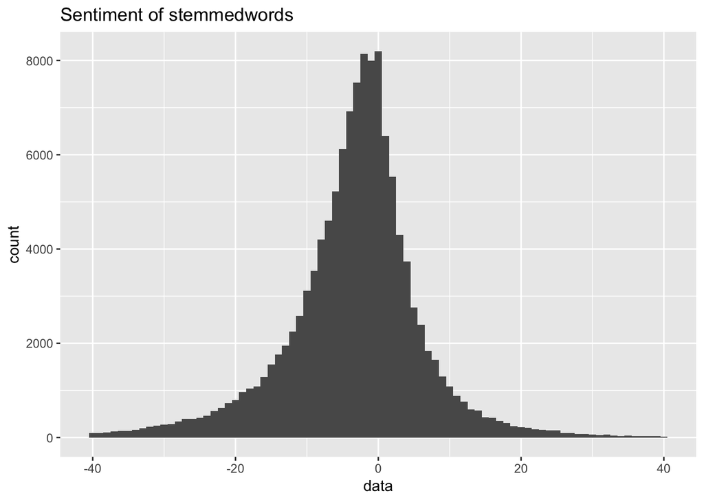

```r
#sentiment analysis
positives= readLines("positive-words.txt")
negatives = readLines("negative-words.txt")

# Let's have error handling function when trying tolower
tryTolower = function(x){
  # create missing value
  y = NA
  # tryCatch error
  try_error = tryCatch(tolower(x), error=function(e) e)
  # if not an error
  if (!inherits(try_error, "error"))
    y = tolower(x)
  # result
  return(y)
}

scores = lapply(to_score,function(songs, positive_words=positives, negative_words=negatives){
                 songs = sapply(songs, tryTolower)
                 # compare words to the dictionaries of positive & negative terms
                 positive.matches = match(songs, positive_words)
                 negative.matches = match(songs, negative_words)
                 # get the position of the matched term or NA
                 # we just want a TRUE/FALSE
                 positive_matches = !is.na(positive.matches)
                 negative_matches = !is.na(negative.matches)
                 # final score
                 score = sum(positive_matches) - sum(negative_matches)
                 return(score)
               })

score <- unlist(scores)

##?????????-40???40????????????
plot_score <- score[score>=-40&score<=40]
theplot <-data.frame(data=plot_score)
ggplot(theplot,aes(x=data)) + geom_histogram(binwidth=1) + ggtitle("Sentiment of stemmedwords")
```

1. Wordcloud and Word Frequency Wordcloud visualizations make it easy to read and understand the most prominent term.

At first, we used processed lyrics data to produce wordcloud.The most frequent words are love, time, baby, life and heart. Additionally, love takes a large part of lyrics. This result is highly accordance with our daily life. For most people, we need to release our emotions through music.

Second, i plot the frequencies of most common 30 words. The results are quite similar from wordcloud and my plot.

2.Sentiment Analysis

B. Original Data

Then Produce the wordcloud and word frequency of original data which is unprocessed data.

```r
####origin data
load("original_lyrics.RData")

all_word <- lapply(dt_lyrics$lyrics, function(x){
  strsplit(x,' ')
})

all_word <- unlist(all_word)

count_word <-data.frame(table(all_word))
count_word<- count_word[order(count_word$Freq,decreasing = TRUE),]

plot_word <- subset(count_word,count_word$Freq>=20)
frequency_data <- plot_word[order(plot_word$Freq,decreasing = TRUE),][1:30,]
####wordcloud
wordcloud2(plot_word)
```

[interactive chart not shown]

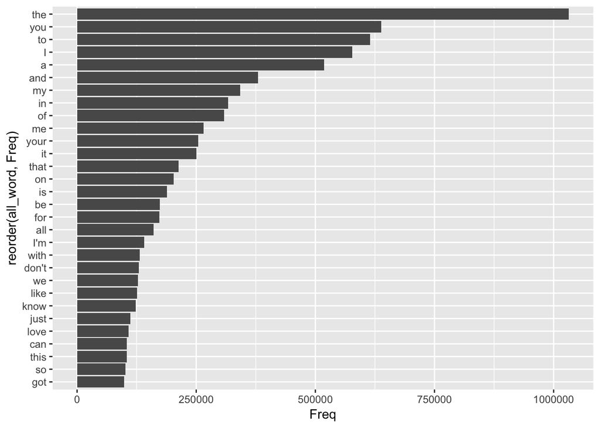

```r
####the first 30 words  histogram
ggplot(frequency_data, aes(x = reorder(all_word,Freq), y = Freq)) +
  geom_bar(stat ="identity")+coord_flip()
```

From the result of wordcloud, we can see the most common words of unprocessed data are the,and,you,of or to and so on. I believe those words cannot release the true feelings from lyrics. However,those words are neccessary parts in every song so it’s reasonable to see them a large portion in our lyrics data. In addition, the word frequency plot also explains the same results.

C. Summary

In summary, lyrics indeed plays a large part in human life. People can release their emotions through lyrics no matter positive sentiment or negative sentiment. Lyrics is not just plain words but a solace to this complicated world.